# A Complete End-to-End Workflow for untargeted LC-MS/MS Metabolomics Data Analysis in R

# Differential abundance analysis

After normalization and quality control, the next step is to identify features that are differentially abundant between the study groups. This crucial step allows us to identify potential biomarkers or metabolites that are associated with the study groups. There are various approaches and methods available for the identification of such features of interest. In this workflow we use a multiple linear regression analysis to identify features with significantly difference in abundances between the CVD or CTR study group.

Before performing the tests we evaluate similarities between study samples using a PCA (after excluding the QC samples to avoid them influencing the results).

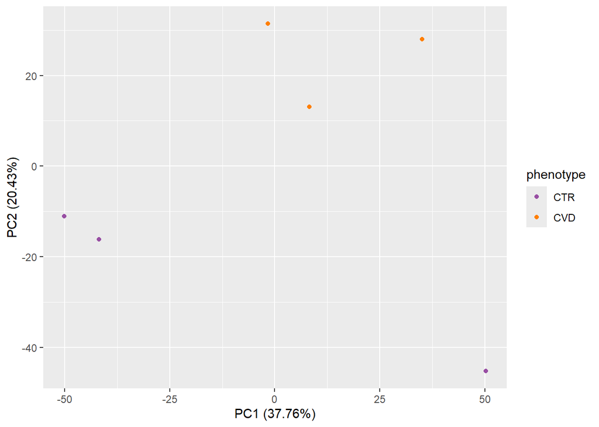

```r
col_sample <- col_phenotype[res$phenotype]

#' Log transform and scale the data for PCA analysis
vals <- assay(res, "norm_imputed") |>
    t() |>
    log2() |>
    scale(center = TRUE, scale = TRUE)
pca_res <- prcomp(vals, scale = FALSE, center = FALSE)

vals_st <- cbind(vals, phenotype = res$phenotype)
autoplot(pca_res, data = vals_st , colour = 'phenotype', scale = 0) +
    scale_color_manual(values = col_phenotype)
```

The samples clearly separate by study group on PCA indicating that there are differences in the metabolite profiles between the two groups. However, what drives the separation on PC1 is not clear. Below we evaluate whether this could be explained by the other available phenotype of our study, age:

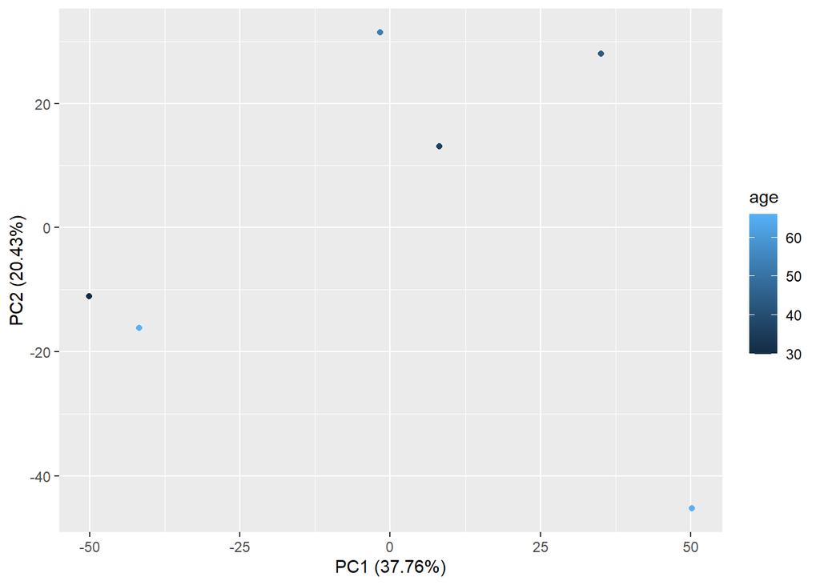

```r
vals_st <- cbind(vals, age = res$age)
autoplot(pca_res, data = vals_st , colour = 'age', scale = 0)
```

Below we define the design of the study with the `model.matrix()` function and fit feature-wise linear models to the log2 transformed abundances using the `lmFit()` function. P-values for significance of association are then calculated using the `eBayes()` function, that also performs the empirical Bayes-based robust estimation of the standard errors. See also the excellent vignette/user guide of the *limma* package for examples and details on the linear model procedure.

```r
#' Define the linear model to be applied to the data
p.cut <- 0.05     # cut-off for significance.
m.cut <- 0.5      # cut-off for log2 fold change

age <- res$age
phenotype <- factor(res$phenotype)
design <- model.matrix(~ phenotype + age)

#' Fit the linear model to the data, explaining metabolite
#' concentrations by phenotype and age.
fit <- lmFit(log2(assay(res, "norm_imputed")), design = design)
fit <- eBayes(fit)
```

After the linear models habe been fitted, we can now proceed to extract the results. We will create a data frame containing the coefficients, raw and adjusted p-values (applying a Benjamini-Hochberg correction, e.g. `method = "BH"` for improved control of the false discovery rate), the average intensity of signals in CVD and CTR samples, and an indication of whether a feature is deemed significant or not. We consider all metabolites with an adjusted p-value smaller than 0.05 to be significant, but we could also include the (absolute) difference in abundances in the cut-off criteria. At last we add the differential abundance results to the result object’s `rowData()`.

```r
#' Compile a result data frame
tmp <- data.frame(
    coef.CVD = fit$coefficients[, "phenotypeCVD"],
    pvalue.CVD = fit$p.value[, "phenotypeCVD"],
    adjp.CVD = p.adjust(fit$p.value[, "phenotypeCVD"], method = "BH"),
    avg.CVD = rowMeans(
        log2(assay(res, "norm_imputed")[, res$phenotype == "CVD"])),
    avg.CTR = rowMeans(
        log2(assay(res, "norm_imputed")[, res$phenotype == "CTR"]))
)
tmp$significant.CVD <- tmp$adjp.CVD < 0.05
#' Add the results to the object's rowData
rowData(res) <- cbind(rowData(res), tmp)
```

We can now proceed to visualize the distribution of the raw and adjusted p-values.

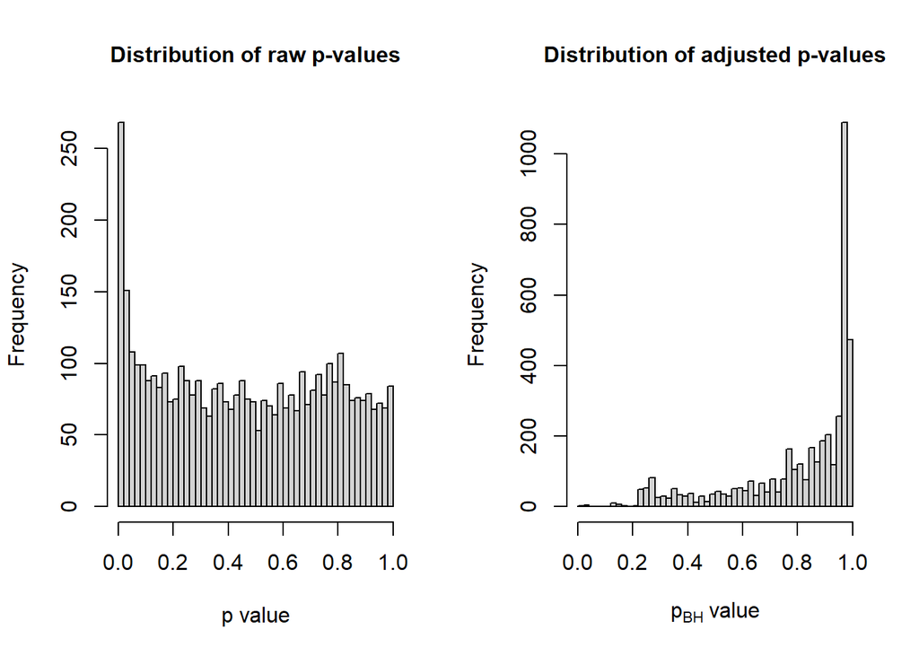

Distribution of raw (left) and adjusted p-values (right).

The histograms above show the distribution of raw and adjusted p-values. Except for an enrichment of small p-values, the raw p-values are (more or less) uniformly distributed, which indicates the absence of any strong systematic biases in the data. The adjusted p-values are more conservative and account for multiple testing which is important here as we fit a linear model to each feature and therefore perform a large number of tests which leads to a high chance of false positive findings. We do see that some features have very low p-values, indicating that they are likely to be significantly different between the two study groups.

Below we plot the adjusted p-values against the log2 fold change of (average) abundances. This volcano plot will allow us to visualize the features that are significantly different between the two study groups. These are highlighted with a blue color in the plot below.

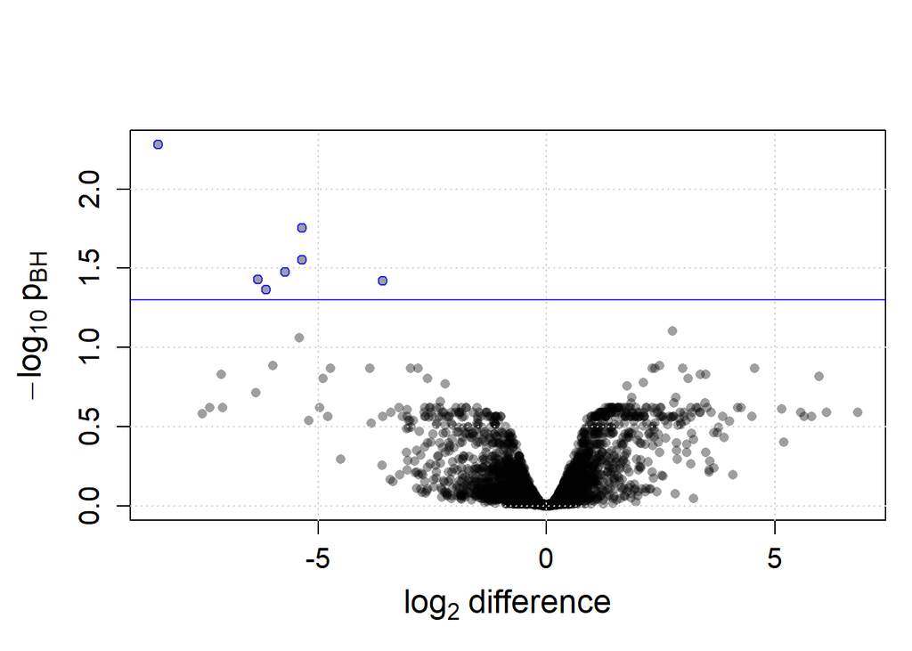

Volcano plot showing the analysis results.

The most interesting features are in the top corners in the volcano plot (i.e., features with a large difference in abundance between the groups and a small p-value). All significant features have a negative coefficient (log2 fold change value) indicating that their abundance is lower in CVD samples compared to the control samples. These features are listed, along with their average difference in (log2) abundance between the compared groups, their adjusted p-values, their average (log2) abundance in each sample group and their RSD (CV) in QC samples in the table below.

Table 7.Features with significant differences in abundances. (continued below)

|  | mzmed | rtmed | coef.CVD | adjp.CVD | avg.CTR | avg.CVD |
| --- | --- | --- | --- | --- | --- | --- |
| **FT0732** | 182.1 | 34.84 | -8.521 | 0.005238 | 12.23 | 3.818 |
| **FT0845** | 195.1 | 32.66 | -6.334 | 0.03712 | 16.9 | 10.45 |
| **FT0676** | 176 | 147.6 | -6.145 | 0.04327 | 8.786 | 2.556 |
| **FT0565** | 161 | 162.1 | -5.741 | 0.03327 | 10.28 | 4.318 |
| **FT0371** | 138.1 | 148.4 | -5.37 | 0.02803 | 9.912 | 4.175 |
| **FT1171** | 229.1 | 181.1 | -5.361 | 0.01763 | 10.72 | 5.539 |
| **FT5606** | 560.4 | 33.55 | -3.593 | 0.03784 | 8.883 | 5.072 |

|  | qc_cv |
| --- | --- |
| **FT0732** | 0.2103 |
| **FT0845** | 0.02961 |
| **FT0676** | 0.7751 |
| **FT0565** | 0.03597 |
| **FT0371** | 0.5556 |
| **FT1171** | 0.07075 |
| **FT5606** | 1.215 |

Below we visualize the EICs of the significant features to evaluate their (raw) signal. We restrict the MS data set to study samples. Parameter `keepFeatures = TRUE` ensures that identified features are retained in the subset object.

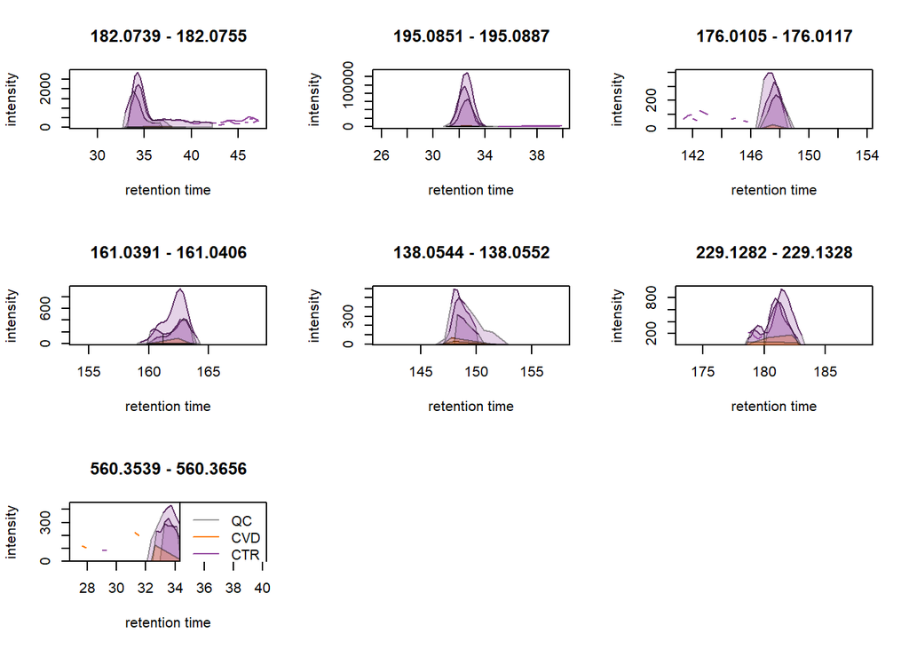

```r
#' Restrict the raw data to study samples.
data_study <- data[sampleData(data)$phenotype != "QC", keepFeatures = TRUE]
#' Extract EICs for the significant features
eic_sign <- featureChromatograms(
    data_study, features = rownames(tab), expandRt = 5, filled = TRUE)

#' Plot the EICs. With parameter `peakBg` we define the (background) color for
#' each individual chromatographic peak in the EIC object.
plot(eic_sign, col = col_sample,
     peakBg = paste0(col_sample[chromPeaks(eic_sign)[, "sample"]], 40))
legend("topright", col = col_phenotype, legend = names(col_phenotype), lty = 1)
```

The EICs for all significant features show a clear and single peak. Their intensities are (as already observed above) much larger in the CTR than in the CVD samples. With the exception of the second feature (second EIC in the top row), the intensities for all significant features are however generally low. This might make it challenging to identify them using an LC-MS/MS setup.

```r
save(data, file = "data_after_DA.RData")
save(res, file = "Sum_Exp_afterDA.RData")
```

# Annotation

We have now identified the features with significant differences in abundances that provide information on metabolic pathways that differentiate affected from healthy individuals and might hence also serve as biomarkers. However, at this stage of the analysis we don’t know what compounds/metabolites they actually represent. We thus need now to annotate these signals. Annotation can be performed at different level of confidence Schymanski et al. (2014). The lowest level of annotation, with the highest rate of false positive hits, bases on the features *m/z* ratios. Higher levels of annotations employ fragment spectra (MS2 spectra) of ions of interest requiring this however acquisition of additional data. In this section we will demonstrate multiple ways to annotate our significant features using functionality provided through Bioconductor packages. Alternative approaches and external software tools, which may be better suited, will also be discussed later in the section.

## MS1 based annotation

Our data set was acquired using an LC-MS setup and our features are thus only characterized by their *m/z* and retention times. The retention time is LC-setup specific and, without prior data/knowledge provide only little information on the features’ identity. Modern MS instruments have a high accuracy and the *m/z* values should therefore be a reliable estimates of the compound ion’s mass-to-charge ratio. As a first approach we use thus the features’ *m/z* values and match them against reference values, i.e. exact masses of chemical compounds, that are provided by a reference database, in our case the MassBank database. The full MassBank data is re-distributed through Bioconductor’s *AnnotationHub* resource, which simplifies their integration into reproducible R-based analysis workflows. Below we load the resource, list allavailable MassBank data sets/releases and load one of them.

```r
#' load reference data
ah <- AnnotationHub()
#' List available MassBank data sets
query(ah, "MassBank")
```

```
## AnnotationHub with 6 records
## # snapshotDate(): 2024-04-29
## # $dataprovider: MassBank
## # $species: NA
## # $rdataclass: CompDb
## # additional mcols(): taxonomyid, genome, description,
## #   coordinate_1_based, maintainer, rdatadateadded, preparerclass, tags,
## #   rdatapath, sourceurl, sourcetype
## # retrieve records with, e.g., 'object[["AH107048"]]'
##
##              title
##   AH107048 | MassBank CompDb for release 2021.03
##   AH107049 | MassBank CompDb for release 2022.06
##   AH111334 | MassBank CompDb for release 2022.12.1
##   AH116164 | MassBank CompDb for release 2023.06
##   AH116165 | MassBank CompDb for release 2023.09
##   AH116166 | MassBank CompDb for release 2023.11
```

```r
#' Load one MAssBank release
mb <- ah[["AH116166"]]
```

The MassBank data is provided as a self-contained SQLite database and data can be queried and accessed through the *CompoundDb* Bioconductor package. Below we use the `compounds()` function to extract small compound annotations from the database.

```r
cmps <- compounds(mb, columns = c("compound_id", "name", "formula",
                                  "exactmass", "inchikey"))
head(cmps)
```

```
##   compound_id       formula exactmass                    inchikey
## 1           1    C27H29NO11  543.1741 AOJJSUZBOXZQNB-UHFFFAOYSA-N
## 2           2      C40H54O4  598.4022 KFNGKYUGHHQDEE-AXWOCEAUSA-N
## 3           3    C10H24N2O2  204.1838 AEUTYOVWOVBAKS-UWVGGRQHSA-N
## 4           4     C16H27NO5  313.1889 LMFKRLGHEKVMNT-UJDVCPFMSA-N
## 5           5 C20H15Cl3N2OS  435.9971 JLGKQTAYUIMGRK-UHFFFAOYSA-N
## 6           6      C15H14O5  274.0841 BWNCKEBBYADFPQ-UHFFFAOYSA-N
##                   name
## 1           Epirubicin
## 2 Crassostreaxanthin A
## 3           Ethambutol
## 4           Heliotrine
## 5        Sertaconazole
## 6    (R)Semivioxanthin
```

MassBank (as most other small compound annotation databases) provide the (exact) molecular mass of each compound. Since almost all small compounds are neutral in their natural state they need to be first converted to *m/z* values to allow matching against the feature’s *m/z*. To calculate an *m/z* from a neutral mass, we need to assume which ion (adduct) might be generated from the measured metabolites by the employed electro-spray ionization. In positive polarity, for human serum samples, the most common ions will be protonated (*[M+H]+*), sodium ions (*[M+Na]+*) or *[M+H-NH3]*) ions. To match the observed *m/z* values against reference values from these potential ions we use the `matchValues()` function from the *MetaboAnnotation* package with the `Mass2MzParam` approach, that allows to specify the types of expected ions with its `adducts` parameter and the maximal allowed difference between the compared values using the `tolerance` and `ppm` parameters. Below we first prepare the data frame with the significant features, set up the parameters for the matching and perform the comparison of the query features against the reference database using the `matchValues()` function. With parameter `mzColname` we specify the name of the column in the query data frame that contains the *m/z* values.

```r
#' Prepare query data frame
rowData(res)$feature_id <- rownames(rowData(res))
res_sig <- res[rowData(res)$significant.CVD, ]

#' Setup parameters for the matching
param <- Mass2MzParam(adducts = c("[M+H]+", "[M+Na]+", "[M+H-NH3]+"),
                      tolerance = 0, ppm = 5)

#' Perform the matching.
mtch <- matchValues(res_sig, cmps, param = param, mzColname = "mzmed")
mtch
```

```
## Object of class Matched
## Total number of matches: 237
## Number of query objects: 7 (4 matched)
## Number of target objects: 117732 (237 matched)
```

```r
#' Extracting the results
mtch_res <- matchedData(mtch, c("feature_id", "mzmed", "rtmed",
                                "adduct", "ppm_error",
                                "target_formula", "target_name",
                                "target_inchikey"))
mtch_res
```

```
## DataFrame with 240 rows and 8 columns
##         feature_id     mzmed     rtmed      adduct ppm_error target_formula
##        <character> <numeric> <numeric> <character> <numeric>    <character>
## FT0371      FT0371   138.055   148.396      [M+H]+   2.08055        C7H7NO2
## FT0371      FT0371   138.055   148.396      [M+H]+   1.93568        C7H7NO2
## FT0371      FT0371   138.055   148.396      [M+H]+   1.93568        C7H7NO2
## FT0371      FT0371   138.055   148.396      [M+H]+   1.93568        C7H7NO2
## FT0371      FT0371   138.055   148.396      [M+H]+   2.08055        C7H7NO2
## ...            ...       ...       ...         ...       ...            ...
## FT1171      FT1171    229.13  181.0883     [M+Na]+   3.07708      C12H18N2O
## FT1171      FT1171    229.13  181.0883     [M+Na]+   3.07708      C12H18N2O
## FT1171      FT1171    229.13  181.0883     [M+Na]+   3.07708      C12H18N2O
## FT1171      FT1171    229.13  181.0883     [M+Na]+   3.07708      C12H18N2O
## FT5606      FT5606    560.36   33.5492          NA        NA             NA
##          target_name target_inchikey
##          <character>     <character>
## FT0371 Benzohydro...   VDEUYMSGMP...
## FT0371 Trigonelli...   WWNNZCOKKK...
## FT0371 Trigonelli...   WWNNZCOKKK...
## FT0371 Trigonelli...   WWNNZCOKKK...
## FT0371 Salicylami...   SKZKKFZAGN...
## ...              ...             ...
## FT1171 Isoproturo...   PUIYMUZLKQ...
## FT1171 Isoproturo...   PUIYMUZLKQ...
## FT1171 Isoproturo...   PUIYMUZLKQ...
## FT1171 Isoproturo...   PUIYMUZLKQ...
## FT5606            NA              NA
```

Thus, in total 237 ions of compounds in MassBank were matched to our significant features based on the specified tolerance settings. Many compounds, while having a different structure and thus function/chemical property, have an identical chemical formula and thus mass. Matching exclusively on the *m/z* of features will hence result in many potentially false positive hits and is thus considered to provide only low confidence annotation. An additional complication is that some annotation resources, like MassBank, being community maintained, contain a large amount of redundant information. To reduce redundancy in the result table we below iterate over the hits of a feature and keep only matches to unique compounds (identified by their INCHIKEY). The INCHI or INCHIKEY combine information from compound’s chemical formula and structure, so while different compounds can share the same chemical formula, they should have a different structure and thus INCHI.

```r
rownames(mtch_res) <- NULL

#' Keep only info on features that machted - create a utility function for that
mtch_res <- split(mtch_res, mtch_res$feature_id) |>
    lapply(function(x) {
        lapply(split(x, x$target_inchikey), function(z) {
            z[which.min(z$ppm_error), ]
        })
    }) |>
    unlist(recursive = FALSE) |>
    do.call(what = rbind)

#' Display the results
mtch_res |>
    as.data.frame() |>
    pandoc.table(style = "rmarkdown", caption = "Table 8.MS1 annotation results")
```

Table 8.MS1 annotation results (continued below)

| feature_id | mzmed | rtmed | adduct | ppm_error | target_formula |
| --- | --- | --- | --- | --- | --- |
| FT0371 | 138.1 | 148.4 | [M+H]+ | 1.936 | C7H7NO2 |
| FT0371 | 138.1 | 148.4 | [M+H]+ | 1.936 | C7H7NO2 |
| FT0371 | 138.1 | 148.4 | [M+H]+ | 1.936 | C7H7NO2 |
| FT0371 | 138.1 | 148.4 | [M+H]+ | 1.936 | C7H7NO2 |
| FT0371 | 138.1 | 148.4 | [M+H]+ | 1.936 | C7H7NO2 |
| FT0371 | 138.1 | 148.4 | [M+H]+ | 1.936 | C7H7NO2 |
| FT0371 | 138.1 | 148.4 | [M+H]+ | 1.925 | C7H7NO2 |
| FT0371 | 138.1 | 148.4 | [M+H]+ | 1.936 | C7H7NO2 |
| FT0371 | 138.1 | 148.4 | [M+H]+ | 1.936 | C7H7NO2 |
| FT0371 | 138.1 | 148.4 | [M+H]+ | 1.936 | C7H7NO2 |
| FT0371 | 138.1 | 148.4 | [M+H]+ | 1.925 | C7H7NO2 |
| FT0371 | 138.1 | 148.4 | [M+H]+ | 1.936 | C7H7NO2 |
| FT0371 | 138.1 | 148.4 | [M+H]+ | 1.936 | C7H7NO2 |
| FT0371 | 138.1 | 148.4 | [M+H]+ | 1.936 | C7H7NO2 |
| FT0371 | 138.1 | 148.4 | [M+H]+ | 1.936 | C7H7NO2 |
| FT0371 | 138.1 | 148.4 | [M+H]+ | 1.936 | C7H7NO2 |
| FT0565 | 161 | 162.1 | [M+Na]+ | 3.125 | C8H10S |
| FT0845 | 195.1 | 32.66 | [M+H]+ | 0.06147 | C8H10N4O2 |
| FT0845 | 195.1 | 32.66 | [M+H]+ | 0.06147 | C8H10N4O2 |
| FT0845 | 195.1 | 32.66 | [M+H]+ | 0.1866 | C8H10N4O2 |
| FT1171 | 229.1 | 181.1 | [M+Na]+ | 3.077 | C12H18N2O |

| target_name | target_inchikey |
| --- | --- |
| 4-Aminobenzoic acid | ALYNCZNDIQEVRV-UHFFFAOYSA-N |
| 2-PYRIDINECARBOXYLIC ACID METHYL ESTER | NMMIHXMBOZYNET-UHFFFAOYSA-N |
| 4-PYRIDINECARBOXYLIC ACID METHYL ESTER | OLXYLDUSSBULGU-UHFFFAOYSA-N |
| SALICYLALDOXIME | ORIHZIZPTZTNCU-VMPITWQZSA-N |
| ORTHO NITROTOLUENE | PLAZTCDQAHEYBI-UHFFFAOYSA-N |
| 4-PYRIDYL ACETATE | PTZQTYADHHANGW-UHFFFAOYSA-N |
| Salicylaldehyde oxime | PUNVNOQWQQPNES-UHFFFAOYSA-N |
| META NITROTOLUENE | QZYHIOPPLUPUJF-UHFFFAOYSA-N |
| Anthranilic acid | RWZYAGGXGHYGMB-UHFFFAOYSA-N |
| 2-HYDROXYBENZAMIDE | SKZKKFZAGNVIMN-UHFFFAOYSA-N |
| N-Hydroxybenzamide | VDEUYMSGMPQMIK-UHFFFAOYSA-N |
| 3-Pyridylacetic acid | WGNUNYPERJMVRM-UHFFFAOYSA-N |
| Trigonelline | WWNNZCOKKKDOPX-UHFFFAOYSA-N |
| META-AMINOBENZOIC ACID | XFDUHJPVQKIXHO-UHFFFAOYSA-N |
| 3-PYRIDINECARBOXYLIC ACID METHYL ESTER | YNBADRVTZLEFNH-UHFFFAOYSA-N |
| 4-NITROTOLUENE | ZPTVNYMJQHSSEA-UHFFFAOYSA-N |
| BENZYL METHYL SULFIDE | OFQPKKGMNWASPN-UHFFFAOYSA-N |
| Isocaffeine | LPHGQDQBBGAPDZ-UHFFFAOYSA-N |
| Caffeine | RYYVLZVUVIJVGH-UHFFFAOYSA-N |
| 1,3-Benzenedicarboxylic acid, dihydrazide | UTTHLMXOSUFZCQ-UHFFFAOYSA-N |
| Isoproturon | PUIYMUZLKQOUOZ-UHFFFAOYSA-N |

The table above shows the results of the MS1-based annotation process. We can see that four of our significant features were matched to the MassBank database. The matches seem to be pretty accurate with low ppm errors. The deduplication performed above considerably reduced the number of hits for each feature, but the first still matches ions of a large number of compounds (all with the same chemical formula).

Considering in addition retention times in the MS1-based annotation will increase, but requires additional (previous) knowledge and data such as recording of the retention time of the pure standard for a compound on the same LC setup.

While being of low confidence, MS1-based annotation can provide first candidate annotations that could be confirmed or rejected by additional analyses.

## MS2 based annotation

MS1 annotation is a fast and efficient method to annotate features and therefore give a first insight into the compounds that are significantly different between the two study groups. However, it is not always the most accurate. MS2 data can provide a higher level of confidence in the annotation process as it provides, through the observed fragmentation pattern, information on the structure of the compound.

MS2 data can be generated through LC-MS/MS measurement in which MS2 spectra are recorded for ions either in a data dependent acquisition (DDA) or data independent acquisition (DIA) mode. Generally, it is advised to include some LC-MS/MS runs of e.g. QC samples or randomly selected study samples already during the acquisition of the MS1 data that is used for quantification of the signals. As an alternative, or in addition, a post-hoc LC-MS/MS acquisition can be performed to generate the MS2 data needed for annotation. For the present experiment, a separate LC-MS/MS measurement was conducted on QC samples and selected study samples to generate such data using an *inclusion list* of pre-selected ions. These represent features found to be significantly different between CVD and control samples in an initial analysis of the full experiment. We use a subset of this second LC-MS/MS data set to show how such data can be used for MS2-based annotation. In our differential abundance analysis we found features with significantly higher abundances in CTR samples. Consequently, we will utilize the MS2 data obtained from the CTR samples to annotate these significant features.

Below we load the LC-MS/MS data from the experiment and restrict it to data acquired from the CTR sample.

```r
#' Read the sample descriptions from an xlsx sheet
pd <- read_xlsx("data/phenodata-lc-msms.xlsx") |>
    as.data.frame()

pd <- pd[pd$phenotype == "CTR" & pd$ms_mode == "MSMS", ]

msms_data <- readMsExperiment(file.path(MZML_PATH, "/", pd$mzML_file),
                              sampleData = pd)

#' Filter the data to the same RT range as the LC-MS run
msms_data <- filterRt(msms_data, c(10, 240))
```

In total we have 3 LC-MS/MS data files for the control sample, each with a different collision energy to fragment the ions. Below we show the number of MS1 and MS2 spectra for each of the files.

```r
#' check the number of spectra per ms level
spectra(msms_data) |>
    msLevel() |>
    split(spectraSampleIndex(msms_data)) |>
    lapply(table) |>
    do.call(what = cbind)
```

```
##      1    2    3
## 1  186  186  186
## 2 3123 3118 3120
```

We next extract the `Spectra` object with the MS data from the data object and assign a new spectra variable with the employed collision energy, which we extract from the data objects `sampleData`.

```r
ms2_ctr <- spectra(msms_data)
ms2_ctr$collision_energy <-
    sampleData(msms_data)$fragmentation_mode[spectraSampleIndex(msms_data)]
```

We next filter the MS data by first restricting to MS2 spectra and then removing mass peaks from each spectrum with an intensity that is lower than 5% of the highest intensity for that spectrum, assuming that these very low intensity peaks represent background signal.

```r
#' Remove low intensity peaks
low_int <- function(x, ...) {
    x > max(x, na.rm = TRUE) * 0.05
}

ms2_ctr <- filterMsLevel(ms2_ctr, 2L) |>
    filterIntensity(intensity = low_int)
```

We next remove also mass peaks with an *m/z* value greater or equal to the precursor *m/z* of the ion. This puts, for the later matching against reference spectra, more weight on the fragmentation pattern of ions and avoids hits based only on the precursor *m/z* peak (and hence a similar mass of the compared compounds). At last we restrict to the data to spectra with at least two fragment peaks and scale their intensities such that their sum is 1 for each spectrum. While similarity calculations are not affected by this scaling, it makes visual comparison of fragment spectra easier to read.

```r
#' Remove precursor peaks and restrict to spectra with a minimum
#' number of peaks
ms2_ctr <- filterPrecursorPeaks(ms2_ctr, ppm = 50, mz = ">=")
ms2_ctr <- ms2_ctr[lengths(ms2_ctr) > 1] |>
    scalePeaks()
```

Finally, also to speed up the later comparison of the spectra against the reference database, we load the full MS data into memory (by changing the *backend* to `MsBackendMemory`) and *apply* all processing steps performed on this data so far. Keeping the MS data in memory has performance benefits, but is generally not suggested for large data sets. To evaluate the impact for the present data set we print in addition the size of the data object before and after changing the backend.

```r
#' Size of the object before loading into memory
print(object.size(ms2_ctr), units = "MB")
```

```
## 1.7 Mb
```

```r
#' Load the MS data subset into memory
ms2_ctr <- setBackend(ms2_ctr, MsBackendMemory())
ms2_ctr <- applyProcessing(ms2_ctr)

#' Size of the object after loading into memory
print(object.size(ms2_ctr), units = "MB")
```

```
## 5.8 Mb
```

There is thus only a moderate increase in memory demand after loading the MS data into memory (also because we in addition filtered and cleaned the MS2 data).

While we could proceed and match all these experimental MS2 spectra against reference fragment spectra, for our workflow we aim to annotate the features found significant in the differential abundance analysis. The goal is thus to identify the MS2 spectra from the second (LC-MS/MS) run that could represent fragments of the ions of features from the data in the first (LC-MS) run. Our approach is to match MS2 spectra against the significant features determined earlier based on their precursor *m/z* and retention time (given an acceptable tolerance) to the feature’s *m/z* and retention time. This can be easily done using the `featureArea()` function that effectively considers the actual *m/z* and retention time ranges of the features’ chromatographic peaks and therefore increase the chance of finding a correct match. This however also assumes that retention times between the first and second run don’t differ by much. Alternatively, we would need to align the retention times of the second, LC-MS/MS, data set to those of the first.

Below we first extract the *feature area*, i.e. the *m/z* and retention time ranges, for the significant features.

```r
#' Define the m/z and retention time ranges for the significant features
target <- featureArea(data)[rownames(res_sig), ]
target
```

```
##           mzmin    mzmax     rtmin     rtmax
## FT0371 138.0544 138.0552 146.32270 152.86115
## FT0565 161.0391 161.0407 159.00234 164.30799
## FT0676 176.0105 176.0117 146.32270 148.95415
## FT0732 182.0726 182.0756  32.71242  42.28755
## FT0845 195.0799 195.0887  30.73235  35.67337
## FT1171 229.1282 229.1335 178.01450 183.35303
## FT5606 560.3539 560.3656  32.06570  35.33456
```

We next identify the fragment spectra with their precursor *m/z* and retention times within these ranges. We use the `filterRanges()` function that allows to filter a `Spectra` object using multiple ranges simultaneously. We apply this function separately to each feature (row in the above matrix) to extract the MS2 spectra representing fragmentation information of the presumed feature’s ions.

```r
#' Identify for each feature MS2 spectra with their precursor m/z and
#' retention time within the feature's m/z and retention time range
ms2_ctr_fts <- apply(target[, c("rtmin", "rtmax", "mzmin", "mzmax")],
                     MARGIN = 1, FUN = filterRanges, object = ms2_ctr,
                     spectraVariables = c("rtime", "precursorMz"))
lengths(ms2_ctr_fts)
```

```
## FT0371 FT0565 FT0676 FT0732 FT0845 FT1171 FT5606
##     11     12      0     46     21     12      0
```

```r
l <- lengths(ms2_ctr_fts)
#' Combine the individual Spectra objects
ms2_ctr_fts <- concatenateSpectra(ms2_ctr_fts)
#' Assign the feature identifier to each MS2 spectrum
ms2_ctr_fts$feature_id <- rep(rownames(res_sig), l)
```

We have now a `Spectra` object with fragment spectra for the significant features from our differential expression analysis.

We next build our reference data which we need to process the same way as our *query* spectra. We extract all fragment spectra from the MassBank database, restrict to positive polarity data (since also our experiment was acquired in positive polarity) and perform the same processing to the fragment spectra from the MassBank database.

```r
ms2_ref <- Spectra(mb) |>
    filterPolarity(1L) |>
    filterIntensity(intensity = low_int) |>
    filterPrecursorPeaks(ppm = 50, mz = ">=")
ms2_ref <- ms2_ref[lengths(ms2_ref) > 1] |>
    scalePeaks()
```

Note that also here we could switch to a `MsBackendMemory` backend hence loading the full data from the reference database into memory. This could have a positive impact on the performance of the subsequent spectra matching, would however also increase the memory demand of the present analysis.

Now that both the `Spectra` object for the second run and the database spectra have been prepared, we can proceed with the matching process. We use the `matchSpectra()` function from the *MetaboAnnotation* package with the `CompareSpectraParam` to define the settings for the matching. With `requirePrecursor = TRUE` we limit spectra similarity calculations to fragment spectra with a similar precursor *m/z*. With parameters `tolerance = 0.05` and `ppm = 40` we define the acceptable difference between compared *m/z* values. These relaxed tolerance settings ensure that we find matches even if reference spectra were acquired on instruments with a lower accuracy. With parameter `THRESHFUN` we define which matches to report. We keep all matches resulting in a spectra similarity score (calculated with the normalized dot product (Stein and Scott 1994), the default similarity function) larger than 0.6.

```r
register(SerialParam())
#' Define the settings for the spectra matching
prm <- CompareSpectraParam(ppm = 40, tolerance = 0.05,
                           requirePrecursor = TRUE,
                           THRESHFUN = function(x) which(x >= 0.6))

ms2_mtch <- matchSpectra(ms2_ctr_fts, ms2_ref, param = prm)
ms2_mtch
```

```
## Object of class MatchedSpectra
## Total number of matches: 140
## Number of query objects: 102 (10 matched)
## Number of target objects: 69561 (16 matched)
```

Thus, from the in total 102 query MS2 spectra only 10 could be matched to (at least) one reference fragment spectrum.

Below we restrict the results to these matching spectra and extract all metadata of the query and target spectra as well as the similarity score (the complete list of available metadata information could be listed with the `colnames()` function).

```r
#' Keep only query spectra with matching reference spectra
ms2_mtch <- ms2_mtch[whichQuery(ms2_mtch)]

#' Extract the results
ms2_mtch_res <- matchedData(ms2_mtch)
nrow(ms2_mtch_res)
```

```
## [1] 140
```

As a result we got now all query-target pairs with a spectra similarity higher than 0.6. Similar to the MS1-based annotation also this result table contains redundant information: we have multiple fragment spectra per feature and also MassBank contains several fragment spectra for each compound, measured using differing collision energies or MS instruments, by different laboratories. Below we thus iterate over the feature-compound pairs and select for each the one with the highest score. As an identifier for a compound (since compound names in MassBank are not standardized [jo: wrong word; normalized?]) we use its fragment spectra’s InChI-key.

```r
#' - split the result per feature
#' - select for each feature the best matching result for each compound
#' - combine the result again into a data frame
ms2_mtch_res <-
    ms2_mtch_res |>
    split(f = paste(ms2_mtch_res$feature_id, ms2_mtch_res$target_inchikey)) |>
    lapply(function(z) {
        z[which.max(z$score), ]
    }) |>
    do.call(what = rbind) |>
    as.data.frame()

#' List the best matching feature-compound pair
pandoc.table(ms2_mtch_res[, c("feature_id", "target_name", "score",
                              "target_inchikey")],
             style = "rmarkdown",
             caption = "Table 9.MS2 annotation results.",
             split.table = Inf)
```

Table 9.MS2 annotation results.

| feature_id | target_name | score | target_inchikey |
| --- | --- | --- | --- |
| FT0845 | Isocaffeine | 0.8048 | LPHGQDQBBGAPDZ-UHFFFAOYSA-N |
| FT0845 | Caffeine | 0.8926 | NA |
| FT0845 | Caffeine | 0.9998 | RYYVLZVUVIJVGH-UHFFFAOYSA-N |

We below plot the EIC for this feature highlighting the retention time at which the highest scoring MS2 spectra was recorded and create a mirror plot comparing this MS2 spectra to the reference fragment spectra for caffeine.

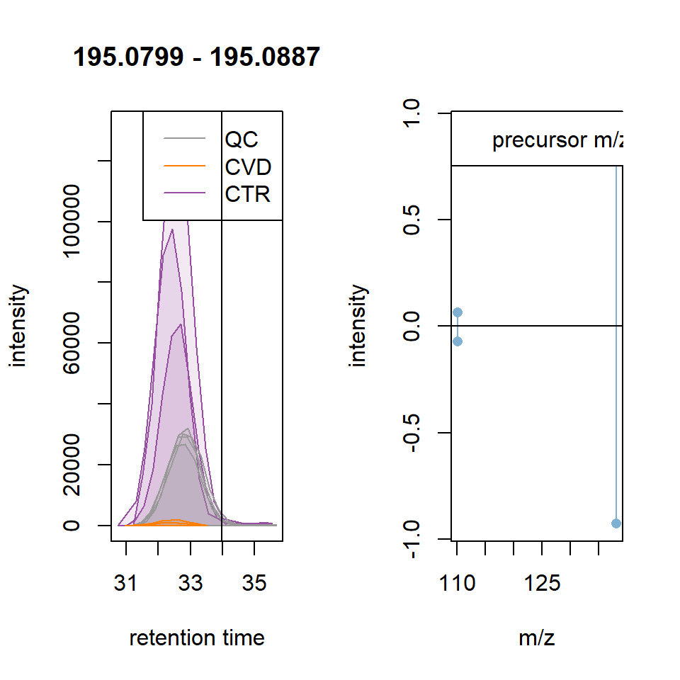

```r
par(mfrow = c(1, 2))

col_sample <- col_phenotype[sampleData(data)$phenotype]
#' Extract and plot EIC for the annotated feature
eic <- featureChromatograms(data, features = ms2_mtch_res$feature_id[1])
plot(eic, col = col_sample, peakCol = col_sample[chromPeaks(eic)[, "sample"]],
     peakBg = paste0(col_sample[chromPeaks(eic)[, "sample"]], 20))
legend("topright", col = col_phenotype, legend = names(col_phenotype), lty = 1)

#' Identify the best matching query-target spectra pair
idx <- which.max(ms2_mtch_res$score)

#' Indicate the retention time of the MS2 spectrum in the EIC plot
abline(v = ms2_mtch_res$rtime[idx])

#' Get the index of the MS2 spectrum in the query object
query_idx <- which(query(ms2_mtch)$.original_query_index ==
                                  ms2_mtch_res$.original_query_index[idx])
query_ms2 <- query(ms2_mtch)[query_idx]
#' Get the index of the MS2 spectrum in the target object
target_idx <- which(target(ms2_mtch)$spectrum_id ==
                                    ms2_mtch_res$target_spectrum_id[idx])
target_ms2 <- target(ms2_mtch)[target_idx]

#' Create a mirror plot comparing the two best matching spectra
plotSpectraMirror(query_ms2, target_ms2)
legend("topleft",
       legend = paste0("precursor m/z: ", format(precursorMz(query_ms2), 3)))
```

The plot above clearly shows the higher signal for this feature in CTR compared to the CVD samples. The signal is lower, but highly similar to each other for the QC samples suggesting absence of strong technical noise or biases in the raw data of this experiment. The vertical line indicates the retention time of the fragment spectrum with the best match against a reference spectrum. It has to be noted that, since the fragment spectra were measured in a separate (LC-MS/MS) experiment, this should only be considered as an indication of the approximate retention time in which ions were fragmented in this second experiment. The fragment spectrum for this feature, shown in the upper panel of the right plot above is highly similar to the reference spectrum for caffeine from MassBank (shown in the lower panel). In addition to their matching precursor *m/z*, the same two fragments (same *m/z* and intensity) are present in both spectra.

We can also extract additional metadata for the matching reference spectrum, such as the used collision energy, fragmentation mode, instrument type, instrument as well as the ion (adduct) that was fragmented.

```r
spectraData(target_ms2, c("collisionEnergy_text", "fragmentation_mode",
                          "instrument_type", "instrument", "adduct")) |>
    as.data.frame()
```

```
##   collisionEnergy_text fragmentation_mode instrument_type
## 1         55 (nominal)                HCD     LC-ESI-ITFT
##                          instrument adduct
## 1 LTQ Orbitrap XL Thermo Scientific [M+H]+
```

## External tools or alternative annotation approaches

An an alternative, or in addition, evidence for the potential matching chemical formula of a feature could be derived by evaluating the isotope pattern of a full MS1 scan of the feature. This could provide information on the isotope composition. Also for this, various functions such as the `itotopologues()` from the or *MetaboCoreUtils* package or the functionality of the *envipat* R package (Loos et al. 2015) could be used.

# Summary

With the present tutorial we describe an end-to-end workflow for a LC-MS based untargeted metabolomics experiments, conducted entirely within R using packages from the Bioconductor project or base R functionality. While other excellent software exist to perform similar analyses, the power of a R-based workflow is the possibility to adapt it to the individual data sets or research questions and to build reproducible workflows respectively documents. Due to space restrictions we don’t provide a comprehensive listing of methodology for the individual analysis steps. More advanced options or approaches would be available e.g. for normalization of the data, which will however also be heavily dependent on the size and properties of the analyzed data set, as well as for annotation of the features.

As a result we found in the present analysis a set of features with significant abundance differences between the compared groups. From these we could however only reliably annotate a single feature. This low proportion of annotated signals is however not uncommon for untargeted metabolomics experiments and reflects the need for more comprehensive, and reliable, reference annotation libraries. Differences observed in the present data sets are related to the lifestyle of individuals rather then to the pathological properties of the investigated disease.

# Appendix

## Alignment using manually selected anchor peaks

- align the data set using internal standards.
- suggested to eventually *enrich* the anchor peaks with signal from other ions in retention time regions not covered by the internal standards.

# Additional informations

```r
#possible extra info:
# -
```

Broadhurst, David, Royston Goodacre, Stacey N. Reinke, Julia Kuligowski, Ian D. Wilson, Matthew R. Lewis, and Warwick B. Dunn. 2018. “Guidelines and Considerations for the Use of System Suitability and Quality Control Samples in Mass Spectrometry Assays Applied in Untargeted Clinical Metabolomic Studies.” *Metabolomics : Official Journal of the Metabolomic Society* 14 (6): 72. https://doi.org/10.1007/s11306-018-1367-3.

De Livera, Alysha M., Daniel A. Dias, David De Souza, Thusitha Rupasinghe, James Pyke, Dedreia Tull, Ute Roessner, Malcolm McConville, and Terence P. Speed. 2012. “Normalizing and Integrating Metabolomics Data.” *Analytical Chemistry* 84 (24): 10768–76. https://doi.org/10.1021/ac302748b.

Dührkop, Kai, Markus Fleischauer, Marcus Ludwig, Alexander A. Aksenov, Alexey V. Melnik, Marvin Meusel, Pieter C. Dorrestein, Juho Rousu, and Sebastian Böcker. 2019. “SIRIUS 4: A Rapid Tool for Turning Tandem Mass Spectra into Metabolite Structure Information.” *Nature Methods* 16 (4): 299–302. https://doi.org/10.1038/s41592-019-0344-8.

Li, Shuzhao, Youngja Park, Sai Duraisingham, Frederick H. Strobel, Nooruddin Khan, Quinlyn A. Soltow, Dean P. Jones, and Bali Pulendran. 2013. “Predicting Network Activity from High Throughput Metabolomics.” *PLoS Computational Biology* 9 (7): e1003123. https://doi.org/10.1371/journal.pcbi.1003123.

Loos, Martin, Christian Gerber, Francesco Corona, Juliane Hollender, and Heinz Singer. 2015. “Accelerated Isotope Fine Structure Calculation Using Pruned Transition Trees.” *Analytical Chemistry* 87 (11): 5738–44. https://doi.org/10.1021/acs.analchem.5b00941.

Nothias, Louis-Félix, Daniel Petras, Robin Schmid, Kai Dührkop, Johannes Rainer, Abinesh Sarvepalli, Ivan Protsyuk, et al. 2020. “Feature-Based Molecular Networking in the GNPS Analysis Environment.” *Nature Methods* 17 (9): 905–8. https://doi.org/10.1038/s41592-020-0933-6.

Rainer, Johannes, Andrea Vicini, Liesa Salzer, Jan Stanstrup, Josep M. Badia, Steffen Neumann, Michael A. Stravs, et al. 2022. “A Modular and Expandable Ecosystem for Metabolomics Data Annotation in R.” *Metabolites* 12 (2): 173. https://doi.org/10.3390/metabo12020173.

Schymanski, Emma L., Junho Jeon, Rebekka Gulde, Kathrin Fenner, Matthias Ruff, Heinz P. Singer, and Juliane Hollender. 2014. “Identifying Small Molecules via High Resolution Mass Spectrometry: Communicating Confidence.” *Environmental Science & Technology* 48 (4): 2097–98. https://doi.org/10.1021/es5002105.

Smyth, Gordon K. 2004. “Linear Models and Empirical Bayes Methods for Assessing Differential Expression in Microarray Experiments.” *Statistical Applications in Genetics and Molecular Biology* 3: Art. 3, 29 pp. (electronic).

Stein, Stephen E., and Donald R. Scott. 1994. “Optimization and Testing of Mass Spectral Library Search Algorithms for Compound Identification.” *Journal of the American Society for Mass Spectrometry* 5 (9): 859–66. https://doi.org/10.1021/jasms.8b00613.

Sumner, Lloyd W., Alexander Amberg, Dave Barrett, Michael H. Beale, Richard Beger, Clare A. Daykin, Teresa W.-M. Fan, et al. 2007. “Proposed Minimum Reporting Standards for Chemical Analysis Chemical Analysis Working Group (CAWG) Metabolomics Standards Initiative (MSI).” *Metabolomics : Official Journal of the Metabolomic Society* 3 (3): 211–21. https://doi.org/10.1007/s11306-007-0082-2.

Tautenhahn, Ralf, Christoph Böttcher, and Steffen Neumann. 2008. “Highly Sensitive Feature Detection for High Resolution LC/MS.” *BMC Bioinformatics* 9 (1): 504. https://doi.org/10.1186/1471-2105-9-504.